# Exploration of the ToothGrowth Dataset

Bojan Zunar

14 July 2018

# 1 Introduction

ToothGrowth is a dataset of 60 observations on three variables: odontoblast length in guinea pigs (*length*), the dose of vitamin C (*dose*), and supplement/delivery method (*supp*). Each animal received one of three dose levels of vitamin C (0.5, 1, and 2 mg/day) by one of two delivery methods, orange juice (*OJ*) or pure ascorbic acid (coded as *VC*) (https://www.rdocumentation.org/packages/datasets/versions/3.5.0/topics/ToothGrowth).

# 2 Exploration of the Dataset

Summary of the dataset shows that the length of odontoblasts varies between 4.20 and 33.90 microns, with a median length of 19.25 microns. However, the boxplot of the data shows that the dose and delivery method affect cell length.

```r
library(magrittr); library(ggplot2); library(dplyr); library(ggsci)

summary(ToothGrowth)
```

```
##       len        supp         dose
##  Min.   : 4.20   OJ:30   Min.   :0.500
##  1st Qu.:13.07   VC:30   1st Qu.:0.500
##  Median :19.25           Median :1.000
##  Mean   :18.81           Mean   :1.167
##  3rd Qu.:25.27           3rd Qu.:2.000
##  Max.   :33.90           Max.   :2.000
```

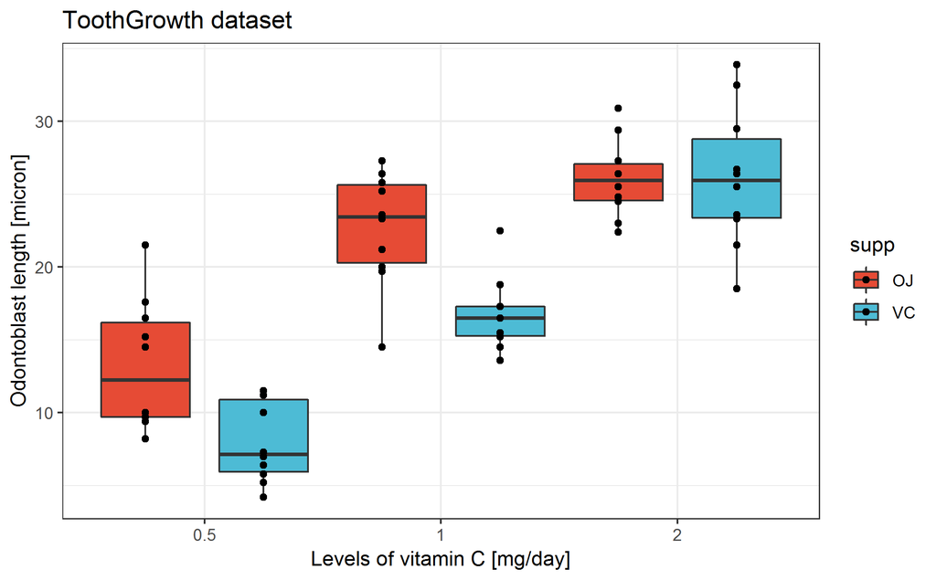

```r
ggplot(ToothGrowth, aes(x = as.factor(dose), y = len, fill = supp)) +
    geom_boxplot(position = position_dodge(1)) + geom_jitter(position = position_dodge(1)) +
    labs(title = "ToothGrowth dataset") + labs(x = "Levels of vitamin C [mg/day]") +
    labs(y = "Odontoblast length [micron]") +
    theme_bw() +
    scale_fill_manual(values = pal_npg("nrc")(2))
```

# 3 Statistical Tests

We performed appropriate t-tests (six in total) to examine the significance of the results. For this purpose, we assume that the test statistic follows the normal distribution. We do not assume that the variances of investigated populations are equal. The p-values were corrected with the `p.adjust` function (stats package, Benjamini & Hochberg correction) to control for the false discovery rate. For convenience, we define appropriate function `tooth_test`.

```r
tooth_test <- function(string, x, y) {
    t.test(x = x$len, y = y$len, alternative = "two.sided",
           paired = FALSE, var.equal = FALSE) %T>%
        {.$conf.int[1:2] ->> conf} %>%
        .$p.value %>%
        p.adjust(method = "BH", n = 6) %>%
        cat(string, "\nCorrected p-value:", .,
            "\n95% confidence interval for difference in the means:", conf)
}
```

First, we examined if orange juice differed from pure vitamin C. Boxplot suggested that **delivery method** influences medians of cell length for doses of 0.5 and 1.0 mg/day of vitamin C. Welch two-sample t-test showed that orange juice yields significantly longer cells, both for **0.5 mg/day** (corrected p-value **0.038**, 95% confidence interval of the difference in means: [1.72, 8.78]) and for **1.0 mg/day** (corrected p-value **0.006**, 95% confidence interval of the difference in means: [2.80, 9.06]). Delivery method has no efect when **2.0 mg/day** was applied (corrected p-value **1.000**, 95% confidence interval of the difference in means: [-3.80, 3.64]).

```r
tooth_test(string = "Orange juice vs ascorbic acid, dose: 0.5 mg/day",
           x = ToothGrowth %>% filter(supp == "OJ" & dose == 0.5),
           y = ToothGrowth %>% filter(supp == "VC" & dose == 0.5))
```

```
## Orange juice vs ascorbic acid, dose: 0.5 mg/day
## Corrected p-value: 0.03815164
## 95% confidence interval for difference in the means: 1.719057 8.780943
```

```r
tooth_test(string = "Orange juice vs ascorbic acid, dose: 1.0 mg/day",
           x = ToothGrowth %>% filter(supp == "OJ" & dose == 1),
           y = ToothGrowth %>% filter(supp == "VC" & dose == 1))
```

```
## Orange juice vs ascorbic acid, dose: 1.0 mg/day
## Corrected p-value: 0.006230255
## 95% confidence interval for difference in the means: 2.802148 9.057852
```

```r
tooth_test(string = "Orange juice vs ascorbic acid, dose: 2.0 mg/day",
           x = ToothGrowth %>% filter(supp == "OJ" & dose == 2),
           y = ToothGrowth %>% filter(supp == "VC" & dose == 2))
```

```
## Orange juice vs ascorbic acid, dose: 2.0 mg/day
## Corrected p-value: 1
## 95% confidence interval for difference in the means: -3.79807 3.63807
```

We also investigated whether larger doses of vitamin C yield significantly longer cells. Welch two-sample t-test showed that this is true when orange juice contains **0.5 mg/day** compared to **1.0 mg/day** of vitamin C (corrected p-value **0.0005**, 95% confidence interval of the difference in means: [-13.42, -5.52]), but not when 1.0 mg/day was compared to 2.0 mg/day of vitamin C in orange juice (corrected p-value **0.24**). However, 1.0 mg/day yielded significant difference when compared to 2.0 mg/day of vitamin C if ascorbic acid was used (corrected p-value **0.0005**, 95% confidence interval of the difference in means: [-13.05, -5.69]).

```r
tooth_test(string = "Orange juice, dose: 0.5 vs 1.0 mg/day",
           x = ToothGrowth %>% filter(supp == "OJ" & dose == 0.5),
           y = ToothGrowth %>% filter(supp == "OJ" & dose == 1))
```

```
## Orange juice, dose: 0.5 vs 1.0 mg/day
## Corrected p-value: 0.0005270951
## 95% confidence interval for difference in the means: -13.41563 -5.524366
```

```r
tooth_test(string = "Orange juice, dose: 1.0 vs 2.0 mg/day",
           x = ToothGrowth %>% filter(supp == "OJ" & dose == 1),
           y = ToothGrowth %>% filter(supp == "OJ" & dose == 2))
```

```
## Orange juice, dose: 1.0 vs 2.0 mg/day
## Corrected p-value: 0.2351709
## 95% confidence interval for difference in the means: -6.531443 -0.1885575
```

```r
tooth_test(string = "Ascorbic acid, dose: 1.0 vs 2.0 mg/day",
           x = ToothGrowth %>% filter(supp == "VC" & dose == 1),
           y = ToothGrowth %>% filter(supp == "VC" & dose == 2))
```

```
## Ascorbic acid, dose: 1.0 vs 2.0 mg/day
## Corrected p-value: 0.0005493362
## 95% confidence interval for difference in the means: -13.05427 -5.685733
```

# 4 Confidence Intervals

Finally, we calculated the **95% confidence interval** for two methods when they delivered **2 mg/day** of vitamin C. The confidence interval for **ascorbic acid** spanned **from 22.71 to 29.57 microns**, while the confidence interval for **orange juice** spanned **from 24.16 to 27.96 microns**.

```r
t.test(x = ToothGrowth %>% filter(supp == "VC" & dose == 2) %>% .$len,
       alternative = "two.sided") %>%
    .$conf.int %>%
    .[1:2] %>%
    cat("Ascorbic acid, 2.0 mg/day, 95% confidence interval:", .)
```

```
## Ascorbic acid, 2.0 mg/day, 95% confidence interval: 22.70791 29.57209
```

```r
t.test(x = ToothGrowth %>% filter(supp == "OJ" & dose == 2) %>% .$len,
       alternative = "two.sided") %>%
    .$conf.int %>%
    .[1:2] %>%
    cat("Orange juice, 2.0 mg/day, 95% confidence interval:", .)
```

```
## Orange juice, 2.0 mg/day, 95% confidence interval: 24.16069 27.95931
```

# 5 Conclusions